# Pre_data_edit

Faith

2023-03-22

In this page, I will be bringing you through the though process while trying to supplement the original data set using [World Ocean Atlas(WOA)](https://www.ncei.noaa.gov/access/world-ocean-atlas-2023/) data set. Using the temperature data set, I will be predicting climate types based on the sea surface temperature and using the salinity data, I will be filling in the NA values in the original data set.

## Setup

### Load packages & plot setup

```r
wd<- setwd(dirname(rstudioapi::getActiveDocumentContext()$path)) # set working directory

library(plyr) # data wrangling
library(dplyr) # data wrangling
library(tidyverse) # data wrangling and management
library(data.table) # To read large csv
library(tidyverse) # data wrangling and management
library(ggplot2) # visualization
library(viridis) # Color palette visualization
library(raster) # Managing spatial data

# Create base map
worldmap <- map_data ("world")# From the tidyverse package

base_world  <- ggplot()+
  coord_fixed() +
  xlab("") + ylab("") +
  geom_polygon(data=worldmap, aes(x=long, y=lat, group=group),
                fill="grey80")+
  theme(panel.grid.major = element_blank(), panel.grid.minor = element_blank(),
        panel.background = element_rect(fill = 'white', colour = 'white'),
        axis.line = element_line(colour = "white"), #legend.position="none",
        axis.ticks=element_blank(), axis.text.x=element_blank(),
        axis.text.y=element_blank())
```

### Loading data sets and manipulating raw WOA data

Since the heading of the raw WOA data is long and not fit for downstream coding, I will be renaming them

```r
samples_df <- fread(paste0(wd,'/DATA/ALL/samples.csv'))

woa23_temp <- fread(paste0(wd,'/DATA/WOA/woa23_decav91C0_t00mn01.csv'))

woa23_sali <- fread(paste0(wd,'/DATA/WOA/woa23_decav91C0_s00mn01.csv'))

colnames(woa23_temp)[1:3] <- c("latitude", "longitude","0")

colnames(woa23_sali)[1:3] <- c("latitude", "longitude","0")
```

## Part 1: Predicting climate types using World Ocean Atlas(WOA) temperature data

### Attempt 1: Match location of WOA and original data set

In this attempt, we will try to extract the Sea surface temperature (SST) by matching the latitude and longitude of the WOA data set and the original one

#### Prepare data for sea surface temperature (SST)

Since not all data points at 0m are available, the next temperature available closest to the surface will be used instead. Only data of up to 100m will be used.

```r
woa23_ss_temp <- cbind(woa23_temp[,1:2], coalesce(!!!woa23_temp[,3:23])) # Fill with non-missing vector until 100m

colnames(woa23_ss_temp) <- c("latitude","longitude","ss_temperature") # Renaming the columns to match sample data
```

#### Rounding latitude and longitude to nearest 0.5

The WOA data points provided are in 0.5 intervals (no whole numbers), hence the latitude and longitude of the originial data set will be rounded off to its nearest 0.5 to match the WOA data set.

```r
# Function to round latitude and longitude values to its nearest 0.5 value
round_05<- function(value){
  value_1<- value + 0.5
  value_2<- round(value_1,0)
  value_3<- value_2 -0.5

  return(value_3)
}

# To find out the 0.5 rounded off lat and long for each sample
samples_df_round<- samples_df%>%
  dplyr::select(file_code,longitude,latitude) %>%
  as.data.frame()

samples_df_round[,c("latitude","longitude")] <- lapply(samples_df[,c("latitude","longitude")], round_05)
```

#### Adding SST column to each location by matching location

```r
samples_df_sst<-merge(samples_df_round, woa23_ss_temp, by = c("latitude", "longitude"), all.x = T)
```

#### Checking quality of match

```r
summary(samples_df_sst$ss_temperature)
```

```
##    Min. 1st Qu.  Median    Mean 3rd Qu.    Max.    NA's
##  -1.874   0.978  12.012  11.940  19.456  29.525    1498
```

Out of the 3128 samples, 1498 does not have a match in SST. However, after plotting where the samples lie in relation to the available data, we noticed that many of them lie in coastal areas, very near existing WOA data, hence an alternative method will be employed to match the SST to the samples instead.

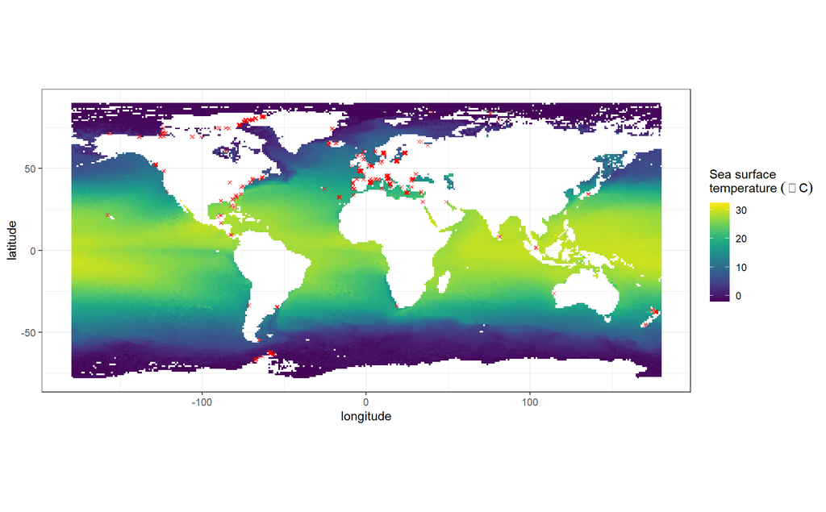

Fig 1: Sample with no WOA sea surface temperature match

```r
# Filtering for NA SST
samples_df_sst_na <- samples_df_sst[rowSums(is.na(samples_df_sst)) > 0,]

# Plotting location of NA values
ggplot() + geom_raster(data = woa23_ss_temp, aes(x=longitude, y = latitude, fill=ss_temperature)) +
  coord_fixed(ratio = 1) +
  geom_jitter(data=samples_df_sst_na,aes(x=longitude, y = latitude),size=1,shape=4,color="red")+
  labs(fill= expression("Sea surface \ntemperature "( ~degree~C))) +
  scale_fill_viridis() +
  theme_bw()
```

```r
ggsave(filename=paste0(wd,"/PLOTS/Pre/sst_Na_location.pdf"),width=40,height=19,units=c("cm"))
```

### Attempt 2: Find WOA grid with values closest to the sample point

Since we know that points without a match lies very close to an existing WOA grid, we can interpolate SST by obtaining the value of the nearest neighbour. We will find which grid closest to the point has a filled in value and extract that value.

#### Find the index of which WOA grid is the closest to each point

```r
woa23_ss_temp <- woa23_ss_temp[,c("longitude", "latitude", "ss_temperature")] # Rearrange lat and long

min_dist<- cbind(samples_df[,c("longitude","latitude")],index=data.frame(apply(raster::pointDistance(as.matrix(samples_df[,c("longitude","latitude")]),
                            as.matrix(woa23_ss_temp[,c("longitude","latitude")]),
                            lonlat = T), 1,which.min)))
```

#### Add WOA SST to sample location using indexing

```r
names(min_dist)<- c("longitude",'latitude',"index")

woa23_ss_temp$index <- 1:nrow(woa23_ss_temp)

min_dist_sst<- min_dist %>%
  merge(woa23_ss_temp, by = 'index', all.x = TRUE)

# Create a dataframe with only file_code, lat and long data
samples_df_location<- samples_df %>%
  dplyr::select(file_code,latitude,longitude)
```

#### Adding SST to original data set

```r
# Combining sst to file code using latitude and longitude and then aggregating repeats
asv_sample_woa_sst_location<- samples_df_location %>%
  merge(., min_dist_sst[,c(2,3,6)], by.x = c('longitude','latitude'),
        by.y = c("longitude.x","latitude.x"),all.x = T,allow.cartesian=TRUE)%>%
  dplyr::group_by(file_code,longitude,latitude,ss_temperature) %>%
  dplyr::summarise(total_count=n(),.groups = 'drop')%>%
  dplyr::select( -total_count) %>%
  as.data.frame()

# Adding sst to original dataset
samples_df<-merge(samples_df, asv_sample_woa_sst_location[,c("file_code","ss_temperature")], by = c("file_code"), all.x = T)
```

#### Checking quanilty of match

```r
summary(samples_df$ss_temperature)
```

```
##    Min. 1st Qu.  Median    Mean 3rd Qu.    Max.    NA's
##  -1.874   2.208  13.078  11.611  17.707  29.525       1
```

This time round, there is only 1 NA out of the 3128 samples which is significantly better than attempt 1.

### Updating climate column using annual SST data

```r
# replacing climate column using annual temp data
samples_df <- mutate(samples_df, climate = case_when((ss_temperature > 18 ) ~ "tropical",
                                                               (ss_temperature < 10 ) ~ "polar",
                                                               (ss_temperature >= 10 & ss_temperature <= 18) ~ "temperate"))
```

#### Plot distribution of climate

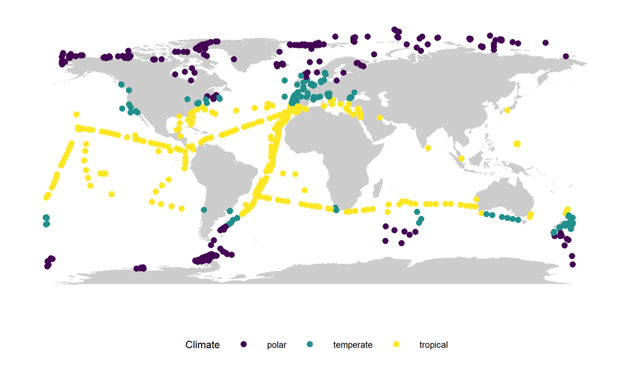

Fig 2: Distribution of cliamtes types accoding to sea surface temperature

```r
# Plot
# Plot distribution of climate type
base_world +
  geom_jitter(data = subset(samples_df, !is.na(climate)), aes(x = longitude, y = latitude,color = climate), size = 3,
             shape = 16)+
  guides(color=guide_legend(title="Climate"))+
  scale_color_viridis_d()+
  theme_minimal()+
  theme(legend.key.size = unit(1.5, 'cm'),
        legend.title = element_text(size=12),
        legend.text = element_text(size=10),
        legend.position = "bottom",
        panel.grid.major = element_blank(),
        panel.grid.minor = element_blank(),
        axis.text.x=element_blank(),
        axis.text.y=element_blank())
```

```r
ggsave(filename=paste0(wd,"/PLOTS/Pre/Climate_type_map.pdf"),width=40,height=19,units=c("cm"),bg="white")
```

## Part 2: Filling in salinity data using WOA salinity data set

### Find WOA grid with values closest to the sample point

Previously, we found that matching a sample point to the closest WOA grid is the most effective method, hence we will replicate this for the salinity data set

#### Prepare WOA sea surface salinity data

```r
# Coalesce WOA data, maximum depth of 100m and extract the salinty at 0m
woa23_sali_coalesce<- cbind(woa23_sali[,1:2],
                                 salinity = as.data.frame(coalesce(!!!woa23_sali[,3:length(woa23_sali)])))

names(woa23_sali_coalesce)[3] <- "salinity"
```

#### Find the index of which WOA grid is the closest to each point

```r
woa23_sali_coalesce <- woa23_sali_coalesce[,c("longitude", "latitude", "salinity")]

s_min_dist<- cbind(samples_df[,c("longitude","latitude")],
                   index=data.frame(apply(raster::pointDistance(as.matrix(samples_df[,c("longitude","latitude")]),
                                                                as.matrix(woa23_sali_coalesce[,c("longitude","latitude")]),
                                                                lonlat = T), 1,which.min)))
```

```r
names(s_min_dist)<- c("longitude",'latitude',"index")

woa23_sali_coalesce$index <- 1:nrow(woa23_sali_coalesce)

s_min_dist<- s_min_dist%>%
  merge(woa23_sali_coalesce, by = 'index', all.x = TRUE)
```

```r
# Combining sst to file code and aggregating repeats
asv_sample_woa_sali_location<- samples_df_location %>%
  merge(., s_min_dist[c(2,3,6)], by.x = c('longitude','latitude'),
        by.y = c("longitude.x","latitude.x"),all.x = T,allow.cartesian=TRUE)%>%
  dplyr::group_by(file_code,longitude,latitude,salinity) %>%
  dplyr::summarise(total_count=n(),.groups = 'drop')%>%
  dplyr::select( -total_count) %>%
  dplyr::rename("salinity_woa"="salinity")%>%
  as.data.frame()

# Adding sali to original dataset
samples_df<-merge(samples_df, asv_sample_woa_sali_location[,c("file_code","salinity_woa")], by = c("file_code"), all.x = T)
```

### Filling NA values in salinity using WOA data and removing extremes

```r
samples_df<- cbind(samples_df,
                        as.data.frame(coalesce(!!!samples_df[,c("salinity","salinity_woa")])))

names(samples_df)[50] <- "coalesce_salinity"

# Removing extreme values of salinity with NA >40
samples_df$salinity[samples_df$salinity > 40] <- NA
samples_df$salinity_woa[samples_df$salinity_woa > 40] <- NA
samples_df$coalesce_salinity[samples_df$coalesce_salinity > 40] <- NA
```

### Exporting updated samples data set

The updated data set with the additional information will be exported. The data from this data set will be merged with the Eukaryotic data set downloaded from MetaPR<sup>2</sup> for further analysis

```r
## Export updated sample dataset to csv
write.csv(samples_df, paste0(wd,'/DATA/ALL/samples_edit.csv'), row.names=FALSE)
```